# **NBA Player Salary Analysis**

[figure not shown]

# Objective

#### The **National Basketball Association (NBA)** oversees player contracts and compensation across the 30 teams in the league. With player salaries representing the largest expense for NBA franchises, understanding the key drivers behind salary growth and predicting future trends is critical for the NBA's financial planning and strategy.

#### This proposed research aims to conduct an in-depth analysis of NBA player salaries over the past decade. The objective is to identify the main factors that have contributed to the substantial growth in average and total player salaries across the league. These insights will help the NBA better grasp the forces that shape team spending on player contracts so the league can plan accordingly when negotiating collective bargaining agreements.

```python
# Import neccessary libraries
import pandas as pd
import numpy as np
import matplotlib.pyplot as plt
import seaborn as sns
import scipy.cluster.hierarchy as sch
from scipy.cluster.hierarchy import fcluster, dendrogram, linkage
from sklearn.metrics import silhouette_score
from sklearn.cluster import KMeans
from sklearn.neighbors import NearestNeighbors
from sklearn.cluster import DBSCAN
from sklearn.preprocessing import StandardScaler
from sklearn.neighbors import KNeighborsClassifier
```

```python
# Turn off all warnings
import warnings
warnings.filterwarnings('ignore')
```

```python
# Load dataset
data_df = pd.read_csv('nba_salaries.csv')
```

```python
# First 10 values of the dataset
data_df.head()
```

|  | Unnamed: 0 | Player Name | Salary | Position | Age | Team | GP | GS | MP | FG | ... | ORB | DRB | TRB | AST | STL | BLK | TOV | PF | PTS | Player-additional |
| --- | --- | --- | --- | --- | --- | --- | --- | --- | --- | --- | --- | --- | --- | --- | --- | --- | --- | --- | --- | --- | --- |
| 0 | 0 | Stephen Curry | 48070014 | PG | 34 | GSW | 56 | 56 | 34.7 | 10.0 | ... | 0.7 | 5.4 | 6.1 | 6.3 | 0.9 | 0.4 | 3.2 | 2.1 | 29.4 | curryst01 |
| 1 | 1 | John Wall | 47345760 | PG | 32 | LAC | 34 | 3 | 22.2 | 4.1 | ... | 0.4 | 2.3 | 2.7 | 5.2 | 0.8 | 0.4 | 2.4 | 1.7 | 11.4 | walljo01 |
| 2 | 2 | Russell Westbrook | 47080179 | PG | 34 | LAL/LAC | 73 | 24 | 29.1 | 5.9 | ... | 1.2 | 4.6 | 5.8 | 7.5 | 1.0 | 0.5 | 3.5 | 2.2 | 15.9 | westbru01 |
| 3 | 3 | LeBron James | 44474988 | PF | 38 | LAL | 55 | 54 | 35.5 | 11.1 | ... | 1.2 | 7.1 | 8.3 | 6.8 | 0.9 | 0.6 | 3.2 | 1.6 | 28.9 | jamesle01 |
| 4 | 4 | Kevin Durant | 44119845 | PF | 34 | BRK/PHO | 47 | 47 | 35.6 | 10.3 | ... | 0.4 | 6.3 | 6.7 | 5.0 | 0.7 | 1.4 | 3.3 | 2.1 | 29.1 | duranke01 |

5 rows × 32 columns

```python
# Reading the column names.
data_df.columns
```

```
Index(['Unnamed: 0', 'Player Name', 'Salary', 'Position', 'Age', 'Team', 'GP',
       'GS', 'MP', 'FG', 'FGA', 'FG%', '3P', '3PA', '3P%', '2P', '2PA', '2P%',
       'eFG%', 'FT', 'FTA', 'FT%', 'ORB', 'DRB', 'TRB', 'AST', 'STL', 'BLK',
       'TOV', 'PF', 'PTS', 'Player-additional'],
      dtype='object')
```

```python
# Renaming the column names for better understanding
data_df = data_df.rename(columns = {"GP":"Games_Played","GS":"Game_Started","MP":"Minutes","FG":"Field_Goals",
                          "FGA":"Field_Goal_Attempts","FG%":"Field_Goals%","eFG%":"Effective_Field_Goal%",
                          "FT":"Free_Throws","FTA":"Free_Throw_Attempts","FT%":"Free_Throw%",
                          "ORB":"Offensive_Rebounds","DRB":"Defensive_Rebounds","TRB":"Total_Rebounds",
                          "AST":"Assists","STL":"Steals","BLK":"Blocks","TOV":"Turnovers","PF":"Personal_Fouls",
                          "PTS":"Points"})
```

## **Data Exploration**

```python
# Statistical description about the data
data_df.describe()
```

|  | Unnamed: 0 | Salary | Age | Games_Played | Game_Started | Minutes | Field_Goals | Field_Goal_Attempts | Field_Goals% | 3P | ... | Free_Throw% | Offensive_Rebounds | Defensive_Rebounds | Total_Rebounds | Assists | Steals | Blocks | Turnovers | Personal_Fouls | Points |
| --- | --- | --- | --- | --- | --- | --- | --- | --- | --- | --- | --- | --- | --- | --- | --- | --- | --- | --- | --- | --- | --- |
| count | 467.000000 | 4.670000e+02 | 467.000000 | 467.000000 | 467.000000 | 467.000000 | 467.000000 | 467.000000 | 466.000000 | 467.000000 | ... | 444.000000 | 467.000000 | 467.000000 | 467.000000 | 467.000000 | 467.000000 | 467.000000 | 467.000000 | 467.000000 | 467.000000 |
| mean | 233.000000 | 8.416599e+06 | 25.820128 | 48.233405 | 22.650964 | 19.871306 | 3.351392 | 7.117773 | 0.465009 | 0.996574 | ... | 0.753489 | 0.866809 | 2.662099 | 3.528051 | 2.107709 | 0.610493 | 0.379015 | 1.114133 | 1.702784 | 9.129979 |
| std | 134.955548 | 1.070812e+07 | 4.275113 | 24.807740 | 27.094577 | 9.548684 | 2.457836 | 5.020700 | 0.109547 | 0.880468 | ... | 0.148659 | 0.746976 | 1.707984 | 2.277160 | 1.957517 | 0.399083 | 0.364387 | 0.830051 | 0.776957 | 6.906006 |
| min | 0.000000 | 5.849000e+03 | 19.000000 | 1.000000 | 0.000000 | 1.800000 | 0.000000 | 0.000000 | 0.000000 | 0.000000 | ... | 0.000000 | 0.000000 | 0.000000 | 0.000000 | 0.000000 | 0.000000 | 0.000000 | 0.000000 | 0.000000 | 0.000000 |
| 25% | 116.500000 | 1.782621e+06 | 23.000000 | 31.000000 | 1.000000 | 12.500000 | 1.600000 | 3.300000 | 0.417000 | 0.300000 | ... | 0.691000 | 0.400000 | 1.400000 | 1.900000 | 0.800000 | 0.300000 | 0.100000 | 0.500000 | 1.200000 | 4.100000 |
| 50% | 233.000000 | 3.722040e+06 | 25.000000 | 55.000000 | 8.000000 | 19.200000 | 2.700000 | 5.800000 | 0.455000 | 0.800000 | ... | 0.769000 | 0.700000 | 2.300000 | 3.000000 | 1.400000 | 0.600000 | 0.300000 | 0.900000 | 1.700000 | 7.100000 |
| 75% | 349.500000 | 1.063354e+07 | 29.000000 | 68.500000 | 45.500000 | 28.300000 | 4.300000 | 9.400000 | 0.507500 | 1.500000 | ... | 0.844000 | 1.100000 | 3.500000 | 4.500000 | 2.900000 | 0.800000 | 0.500000 | 1.500000 | 2.200000 | 11.700000 |
| max | 466.000000 | 4.807001e+07 | 42.000000 | 83.000000 | 83.000000 | 41.000000 | 11.200000 | 22.200000 | 1.000000 | 4.900000 | ... | 1.000000 | 5.100000 | 9.600000 | 12.500000 | 10.700000 | 3.000000 | 2.500000 | 4.100000 | 5.000000 | 33.100000 |

8 rows × 28 columns

```python
# Type of Data types
data_df.info()
```

```
<class 'pandas.core.frame.DataFrame'>
RangeIndex: 467 entries, 0 to 466
Data columns (total 32 columns):
 #   Column                 Non-Null Count  Dtype
---  ------                 --------------  -----
 0   Unnamed: 0             467 non-null    int64
 1   Player Name            467 non-null    object
 2   Salary                 467 non-null    int64
 3   Position               467 non-null    object
 4   Age                    467 non-null    int64
 5   Team                   467 non-null    object
 6   Games_Played           467 non-null    int64
 7   Game_Started           467 non-null    int64
 8   Minutes                467 non-null    float64
 9   Field_Goals            467 non-null    float64
```

[output cut: 24 more lines]

## **Data Cleaning**

```python
# Displaying the total number of NA values of each column
data_df.isnull().sum()
```

```
Unnamed: 0                0
Player Name               0
Salary                    0
Position                  0
Age                       0
Team                      0
Games_Played              0
Game_Started              0
Minutes                   0
Field_Goals               0
Field_Goal_Attempts       0
Field_Goals%              1
3P                        0
3PA                       0
3P%                      13
2P                        0
2PA                       0
2P%                       4
Effective_Field_Goal%     1
Free_Throws               0
Free_Throw_Attempts       0
Free_Throw%              23
Offensive_Rebounds        0
Defensive_Rebounds        0
Total_Rebounds            0
Assists                   0
Steals                    0
Blocks                    0
Turnovers                 0
Personal_Fouls            0
Points                    0
Player-additional         0
dtype: int64
```

```python
# Dropping unwanted columns and null values
df = data_df.drop(columns = ['Unnamed: 0','Field_Goals%','3P%','Free_Throw%','Player-additional'])
df.head()
```

|  | Player Name | Salary | Position | Age | Team | Games_Played | Game_Started | Minutes | Field_Goals | Field_Goal_Attempts | ... | Free_Throw_Attempts | Offensive_Rebounds | Defensive_Rebounds | Total_Rebounds | Assists | Steals | Blocks | Turnovers | Personal_Fouls | Points |
| --- | --- | --- | --- | --- | --- | --- | --- | --- | --- | --- | --- | --- | --- | --- | --- | --- | --- | --- | --- | --- | --- |
| 0 | Stephen Curry | 48070014 | PG | 34 | GSW | 56 | 56 | 34.7 | 10.0 | 20.2 | ... | 5.0 | 0.7 | 5.4 | 6.1 | 6.3 | 0.9 | 0.4 | 3.2 | 2.1 | 29.4 |
| 1 | John Wall | 47345760 | PG | 32 | LAC | 34 | 3 | 22.2 | 4.1 | 9.9 | ... | 3.3 | 0.4 | 2.3 | 2.7 | 5.2 | 0.8 | 0.4 | 2.4 | 1.7 | 11.4 |
| 2 | Russell Westbrook | 47080179 | PG | 34 | LAL/LAC | 73 | 24 | 29.1 | 5.9 | 13.6 | ... | 4.3 | 1.2 | 4.6 | 5.8 | 7.5 | 1.0 | 0.5 | 3.5 | 2.2 | 15.9 |
| 3 | LeBron James | 44474988 | PF | 38 | LAL | 55 | 54 | 35.5 | 11.1 | 22.2 | ... | 5.9 | 1.2 | 7.1 | 8.3 | 6.8 | 0.9 | 0.6 | 3.2 | 1.6 | 28.9 |
| 4 | Kevin Durant | 44119845 | PF | 34 | BRK/PHO | 47 | 47 | 35.6 | 10.3 | 18.3 | ... | 7.1 | 0.4 | 6.3 | 6.7 | 5.0 | 0.7 | 1.4 | 3.3 | 2.1 | 29.1 |

5 rows × 27 columns

#### The columns with NA values and columns which are not important for our analysis have been dropped.

## **Adaptation**

```python
# Finding the the range of the salary and then distributing it into 5 equal parts
salary_difference = df["Salary"].max() - df["Salary"].min()
sections = salary_difference/5

# Classifying the Salary into quintiles and making another column with classified salary
for index, row in df.iterrows():
  if row["Salary"] <= (df["Salary"].min() + sections):
    df.at[index, "Salary_Range"] = "Average"
  elif row["Salary"] <= (df["Salary"].min() + 2*sections):
    df.at[index, "Salary_Range"] = "Above Average"
  elif row["Salary"] <= (df["Salary"].min() + 3*sections):
    df.at[index, "Salary_Range"] = "Excellent"
  elif row["Salary"] <= (df["Salary"].min() + 4*sections):
    df.at[index, "Salary_Range"] = "High"
  else:
    df.at[index, "Salary_Range"] = "Very High"
```

#### **Salary Range:** The salaries of NBA players have been categorised into Average, Above Average, Excellent, High and Very High. This help us understand that how the players are categorised based on their salaries. This categorised data will help the players to work towards their level ups based on salaries.

#### The range of each quintile is as follows:

- **Average:** 5849 to 9,618,682
- **Above Average:** 9,618,683 to 19,231,515
- **Excellent:** 19,231,516 to 28,844,348
- **High:** 28,844,349 to 38,457,181
- **Very High:** 38,457,182 to 48,070,014

```python
# Making a new column called Player Efficiency
df["Player_Efficiency"] = df["Points"] + df["Total_Rebounds"] + df["Assists"] + df["Steals"] + df["Blocks"] - (df["Field_Goal_Attempts"] - df["Field_Goals"]) - (df["Free_Throw_Attempts"] - df["Free_Throws"]) - df["Turnovers"]
```

#### **Player Efficiency:** We have applied formula to calculate the efficiency of each player based on the points scored, Rebounds, Assists, Steals, Blocks, Missed Field Goals, Missed Free Throws and Turnovers. The calculated values has been appended as a new column in the dataset.

#### This column goes over every aspect of a player to give us an overall efficiency score, which will make it easier for us to identify players who are exceptionally good.

#### The formula for calculation of the efficiency is:

#### **Efficiency = Points + Rebounds + Assists + Steals + Blocks – Missed Field Goals – Missed Free Throws – Turnovers**

```python
# Making a new column called Total_Points_Scored, by adding all scored goals
df["Total_Points_Scored"] = (3*df["3P"]) + (2*df["2P"]) + df["Free_Throws"]
```

#### **Total Points Scored:** We have calculated the total number of points scored to understand the total outcome from each player. This score has been added as a new column in the dataset.

#### Formula to calculate Total Points Scored:

#### **Total Points Scored = (3 x 3P) + (2 x 2P) + (1 x Free Throws)**

```python
# Column names of final data set
df.columns
```

```
Index(['Player Name', 'Salary', 'Position', 'Age', 'Team', 'Games_Played',
       'Game_Started', 'Minutes', 'Field_Goals', 'Field_Goal_Attempts', '3P',
       '3PA', '2P', '2PA', '2P%', 'Effective_Field_Goal%', 'Free_Throws',
       'Free_Throw_Attempts', 'Offensive_Rebounds', 'Defensive_Rebounds',
       'Total_Rebounds', 'Assists', 'Steals', 'Blocks', 'Turnovers',
       'Personal_Fouls', 'Points', 'Salary_Range', 'Player_Efficiency',
       'Total_Points_Scored'],
      dtype='object')
```

```python
# Dimension of final data set
df.shape
```

```
(467, 30)
```

#### **The final data set consists of 30 columns and 467 records after cleaning and adaptation.**

## **Descriptive Visualization**

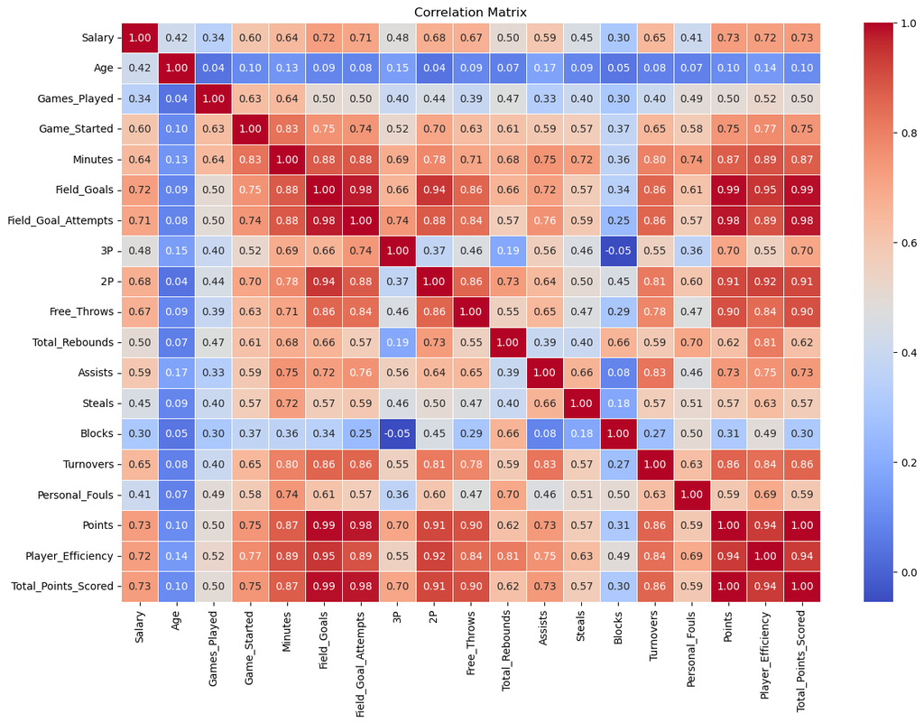

```python
#Selection of specific columns to undersatnd the correlation
df_cor = df[['Salary','Age','Games_Played','Game_Started','Minutes','Field_Goals','Field_Goal_Attempts',
             '3P','2P','Free_Throws','Total_Rebounds','Assists','Steals','Blocks','Turnovers','Personal_Fouls',
             'Points','Player_Efficiency','Total_Points_Scored']]

# Make a correlation matrix of the numerical columns in the dataset
correlation_matrix = df_cor.corr()

# Plot the correlation matrix as a heatmap
plt.figure(figsize=(15, 10))
sns.heatmap(correlation_matrix, annot=True, cmap='coolwarm', fmt=".2f", linewidths=.7)
plt.title('Correlation Matrix')
plt.show()
```

#### **Correlation Matrix:** In statistics refers to degree to which a pair of variables are linearly related. Correlations are useful because they indicate a predictive relationship that can exploited in practice.

#### The above matrix shows us the correlation between each numerical column. We can infer that the salary of an NBA player is highly correlated with Field Goals, Points, Player Efficiency and Total Points Scored.

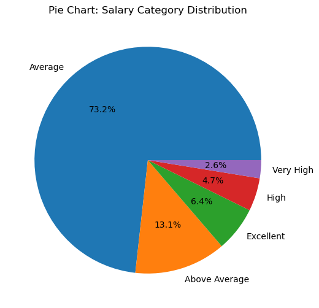

```python
# Count the all the instances in the column "Salary_range"
salary_range = df['Salary_Range'].value_counts()

# Making a pie chart of the Salary Distribution
plt.figure(figsize=(6,6))
plt.pie(salary_range, labels=['Average', 'Above Average', 'Excellent','High','Very High'],autopct='%1.1f%%')
plt.title('Pie Chart: Salary Category Distribution')
plt.show()
```

#### **Salary Categories:**

- Average: 5849 to 9,618,682
- Above Average: 9,618,683 to 19,231,515
- Excellent: 19,231,516 to 28,844,348
- High: 28,844,349 to 38,457,181
- Very High: 38,457,182 to 48,070,014

#### From the salary range column, we have plotted a pie chart which shows us the percentage of players in each category of salary range.

#### We can observe that while 73.2% of players are compensated with average salary:

- 13.1% players have above average salary
- 6.4% players have excellent salary
- 4.7% players have high salary
- 2.6% players have very high salary

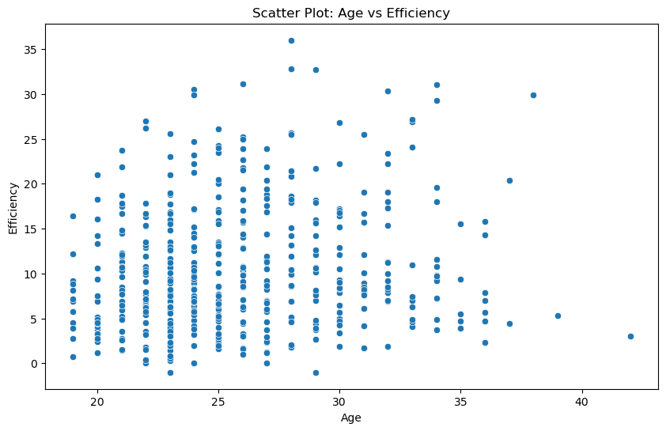

```python
# Scatter plot of Age vs Efficiency of Players
plt.figure(figsize=(10, 6))
sns.scatterplot(x='Age', y='Player_Efficiency', data=df)
plt.title('Scatter Plot: Age vs Efficiency')
plt.xlabel('Age')
plt.ylabel('Efficiency')
plt.show()
```

#### While, as age of players increases, in the range of 35 and above, their efficiency starts dropping down.

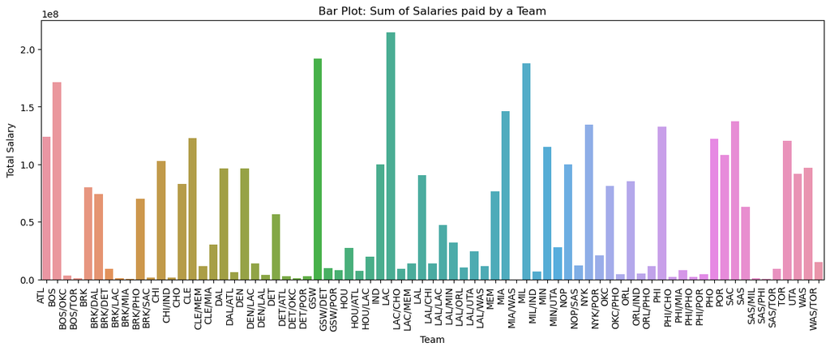

```python
# Group the data by Team Name and Salary
team_points = df.groupby("Team")["Salary"].sum().reset_index()

# Bar plot of the Sum Salary paid by a team
plt.figure(figsize=(15, 5))
sns.barplot(x='Team', y='Salary', data=team_points)
plt.title('Bar Plot: Sum of Salaries paid by a Team')
plt.xlabel('Team')
plt.ylabel('Total Salary')
plt.xticks(rotation=90, ha='right')
plt.show()
```

#### **Salary Distribution:**

#### In the above bar graph, we have grouped all the NBA teams together and we have plotted the sum of salaries paid by each team.

#### From this plot we can conclude that the "Los Angeles Clippers" pay the highest salaries to the players, followed by "Golden State Warriors" and "Milwaukee Bucks". This information will help the players to know which teams pay higher salaries and plan for a switch to get increased pay.

#### **Player's Positioning:**

#### 1. There are different roles/positions of players on the basketball court. Here, the position abbreviations are as follows:

- PG: Point Guard
- SG: Shooting Guard
- SF: Small Forward
- PF: Power Forward
- C: Center

#### 2. Then there are players who play at multiple positions which are:

- PG-SG: Both Point Guard and Shooting Guard
- SF-SG: Both Small Forward and Shooting Guard
- SG-PG: Both Small Guard and Point Guard
- SF-PF: Both Small Forward and Power Forward

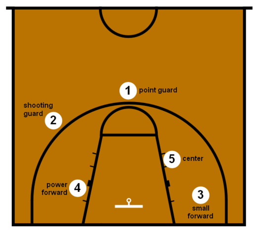

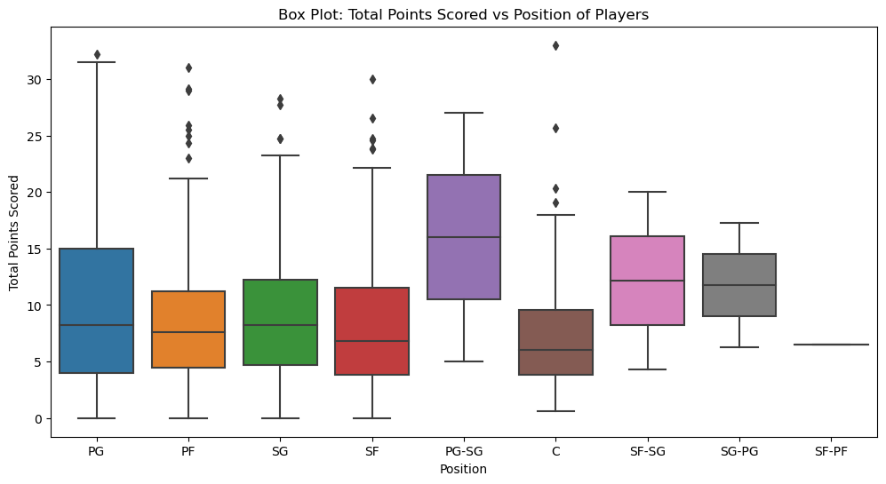

```python
# Box Plot of the Total Points Scored vs the Positions of Players
plt.figure(figsize=(12, 6))
sns.boxplot(x='Position', y='Total_Points_Scored', data=df)
plt.title('Box Plot: Total Points Scored vs Position of Players')
plt.xlabel('Position')
plt.ylabel('Total Points Scored')
plt.show()
```

#### **Player's Position and Scores:**

#### In this box plot above, we can observe the following points:

#### - The players with PG-SG roles have a higher median points. This may indicate that they are consistently strong scorers.

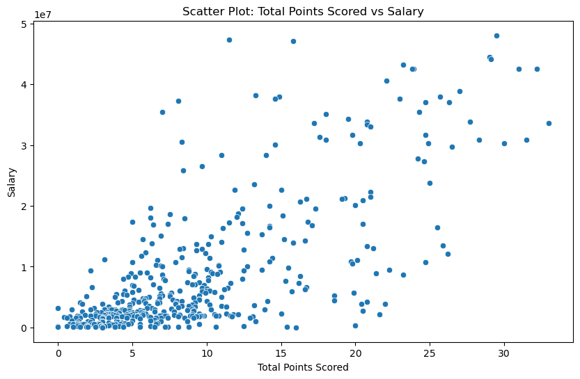

```python
# Scatter plot of Total Points Scored vs Salary
plt.figure(figsize=(10, 6))
sns.scatterplot(x='Total_Points_Scored', y='Salary', data=df)
plt.title('Scatter Plot: Total Points Scored vs Salary')
plt.xlabel('Total Points Scored')
plt.ylabel('Salary')
plt.show()
```

```python
# Column names of final data set
df.columns
```

```
Index(['Player Name', 'Salary', 'Position', 'Age', 'Team', 'Games_Played',
       'Game_Started', 'Minutes', 'Field_Goals', 'Field_Goal_Attempts', '3P',
       '3PA', '2P', '2PA', '2P%', 'Effective_Field_Goal%', 'Free_Throws',
       'Free_Throw_Attempts', 'Offensive_Rebounds', 'Defensive_Rebounds',
       'Total_Rebounds', 'Assists', 'Steals', 'Blocks', 'Turnovers',
       'Personal_Fouls', 'Points', 'Salary_Range', 'Player_Efficiency',
       'Total_Points_Scored'],
      dtype='object')
```

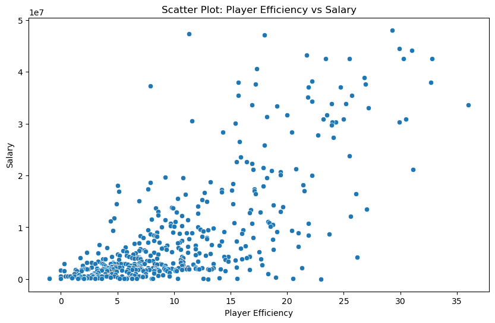

```python
# Scatter plot of Total Points Scored vs Salary
plt.figure(figsize=(10, 6))
sns.scatterplot(x='Player_Efficiency', y='Salary', data=df)
plt.title('Scatter Plot: Player Efficiency vs Salary')
plt.xlabel('Player Efficiency')
plt.ylabel('Salary')
plt.show()
```

#### **Total Points Scored & Salary**

#### The correlation between Salary and Total Points scored by a player is very good and the scatter plot for the same is shown above.

#### We can say that most of the players with good scores are highly paid.

## **Cluster Analysis**

### **Hierarchical clustering:**

```python
#Subset dataframe for Clustering
cluster_data = df[['Player_Efficiency','Salary']]
cluster_data.head()
```

|  | Player_Efficiency | Salary |
| --- | --- | --- |
| 0 | 29.3 | 48070014 |
| 1 | 11.3 | 47345760 |
| 2 | 18.0 | 47080179 |
| 3 | 29.9 | 44474988 |
| 4 | 31.0 | 44119845 |

### **Silhouette Score**

```python
# Range of clusters
min_k = 2
max_k = 11

#Iterate through range of clusters and calculate silhouette score
for n_clusters in range(min_k, max_k, +1):
  kmeans = KMeans(n_clusters = n_clusters, random_state = 0)
  k_clusters = kmeans.fit_predict(cluster_data)
  silhouette_number = silhouette_score(cluster_data, k_clusters)
  print(f"silhouette score for {n_clusters} clusters: {silhouette_number}")
```

```
silhouette score for 2 clusters: 0.7675173265180164
silhouette score for 3 clusters: 0.7016917846073701
silhouette score for 4 clusters: 0.6573668358806352
silhouette score for 5 clusters: 0.6555044872715492
silhouette score for 6 clusters: 0.6043877698901053
silhouette score for 7 clusters: 0.6046896729766441
silhouette score for 8 clusters: 0.5752402844074811
silhouette score for 9 clusters: 0.598537213447241
silhouette score for 10 clusters: 0.6020444041825418
```

#### Silhouette refers to a method of interpretation and validation of consistency within clusters of data. The technique provides a succinct graphical representation of how well each object has been classified.

#### The silhouette value is a measure of how similar an object is to its own cluster (cohesion) compared to other clusters (separation). The silhouette ranges from −1 to +1, where a high value indicates that the object is well matched to its own cluster and poorly matched to neighboring clusters. If most objects have a high value, then the clustering configuration is appropriate.

Reference:- https://en.wikipedia.org/wiki/Silhouette_(clustering)

### The desired number of clusters based on the Silhouette scores is 2.

```python
# Hierarchical Clustering
linkage_method = 'ward'
distance_metric = 'euclidean'

hierarchical_matrix = sch.linkage(cluster_data, method = linkage_method, metric = distance_metric)

desired_num_clusters = 2

# Stop the clusters at a specific distance
cluster_hier = fcluster(hierarchical_matrix, t=desired_num_clusters, criterion = 'maxclust')
```

```python
# Converting the arrays into dataframe
new_clusters = pd.DataFrame({'Clusters':cluster_hier})

# Aadding the new column to the actual dataframe
clustered_data = pd.concat([cluster_data,new_clusters], axis=1)
clustered_data.head()
```

|  | Player_Efficiency | Salary | Clusters |
| --- | --- | --- | --- |
| 0 | 29.3 | 48070014 | 1 |
| 1 | 11.3 | 47345760 | 1 |
| 2 | 18.0 | 47080179 | 1 |
| 3 | 29.9 | 44474988 | 1 |
| 4 | 31.0 | 44119845 | 1 |

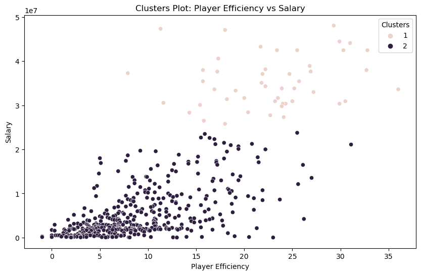

```python
# Scatter plot of Total Points Scored vs Salary
plt.figure(figsize=(10, 6))
sns.scatterplot(x='Player_Efficiency', y='Salary', data=clustered_data, hue = 'Clusters')
plt.title('Clusters Plot: Player Efficiency vs Salary')
plt.xlabel('Player Efficiency')
plt.ylabel('Salary')
plt.show()
```

#### The Hierarchical clustering has mainly clustered the players based on their salaries and the same we can see in the above scatter plot.

### **Dendrogram:**

#### Dendrograms are more effective and readable for small data sets for which we have taken sample data set.

```python
# Random sample Data set
sample_size = 50
deno_df = clustered_data.sample(n = sample_size)
deno_df.head()
```

|  | Player_Efficiency | Salary | Clusters |
| --- | --- | --- | --- |
| 90 | 19.6 | 13906976 | 2 |
| 363 | 1.8 | 1563518 | 2 |
| 67 | 21.4 | 18206896 | 2 |
| 243 | 10.8 | 3261480 | 2 |
| 361 | 3.6 | 1637966 | 2 |

```python
df_matrix = linkage(deno_df, method='centroid')
```

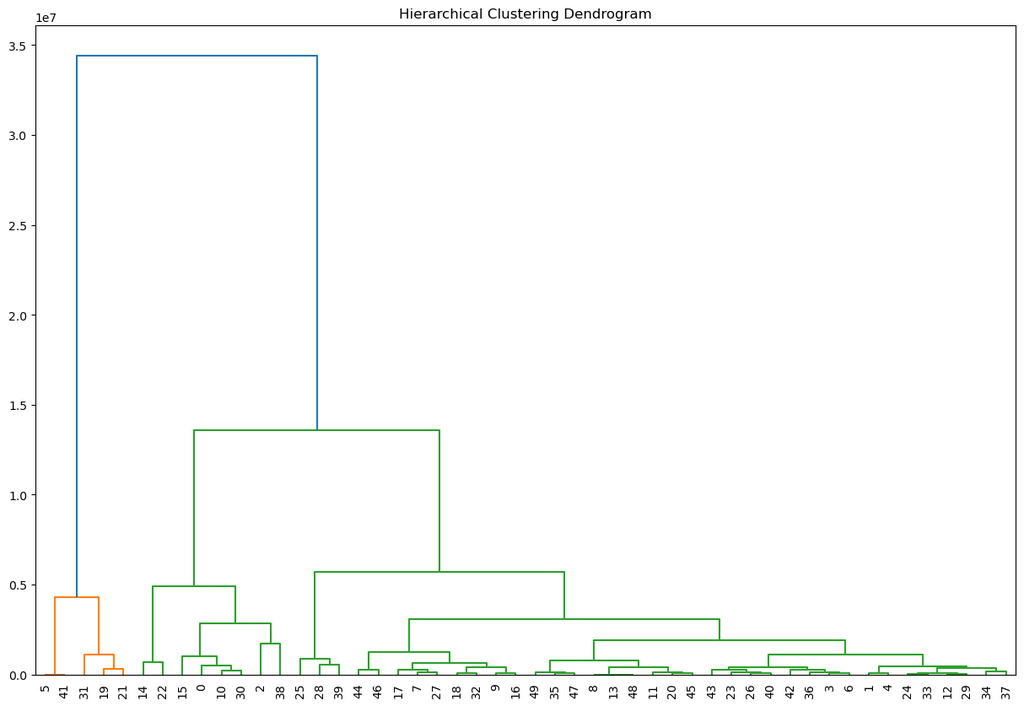

```python
plt.figure(figsize=(15, 10))
plt.title('Hierarchical Clustering Dendrogram')
dendrogram(df_matrix, leaf_font_size=10.)
plt.show()
```

#### The above Dendrogram shows that 2 clusters are formed for the provided sample data set and which is similar outcome from the silhouette score.

```python
df.shape
```

```
(467, 30)
```

## **KMeans**

```python
def kmeans(df, num_clusters):
  kmeans = KMeans(n_clusters = num_clusters, random_state = 0)
  cluster_labels = kmeans.fit_predict(df)

  clustered_data['Clusters'] = cluster_labels
  return df
```

```python
# Based on the silhouette score out come k=3.
k_cluster_df = kmeans(clustered_data, 2)

k_cluster_df.head()
```

|  | Player_Efficiency | Salary | Clusters |
| --- | --- | --- | --- |
| 0 | 29.3 | 48070014 | 1 |
| 1 | 11.3 | 47345760 | 1 |
| 2 | 18.0 | 47080179 | 1 |
| 3 | 29.9 | 44474988 | 1 |
| 4 | 31.0 | 44119845 | 1 |

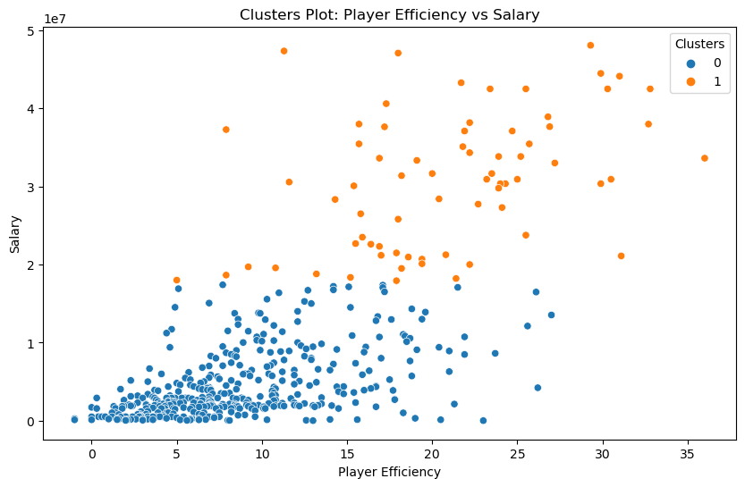

```python
# Scatter plot of Total Points Scored vs Salary
plt.figure(figsize=(10, 6))
sns.scatterplot(x='Player_Efficiency', y='Salary', data=k_cluster_df, hue = 'Clusters')
plt.title('Clusters Plot: Player Efficiency vs Salary')
plt.xlabel('Player Efficiency')
plt.ylabel('Salary')
plt.show()
```

## **KNN Function**

```python
# Creation of subsets

df_1 = df[["Salary", "Player_Efficiency"]]
df_2 = df[["Salary", "Points"]]
df_3 = df[["Salary", "Age"]]
df_4 = df[["Salary", "Minutes"]]
df_5 = df[["Salary", "Total_Rebounds"]]
```

#### We have created 5 subsets of the data to perform KNN on the data

```python
# Train and test data

from sklearn.model_selection import train_test_split
df_1_train, df_1_test = train_test_split(df_1, test_size=67, random_state=42)
df_2_train, df_2_test = train_test_split(df_2, test_size=67, random_state=42)
df_3_train, df_3_test = train_test_split(df_3, test_size=67, random_state=42)
df_4_train, df_4_test = train_test_split(df_4, test_size=67, random_state=42)
df_5_train, df_5_test = train_test_split(df_5, test_size=67, random_state=42)
```

#### The subsets are then split into training and testing data.

#### The size of the test data is set to 67 rows, the remaining 400 rows are allocated to training data.

```python
# Classified Train data - K-Means
def kmeans_clustering(df, num_clusters=3, test_size=67, random_state=42):
    df_train_set, df_test_set = train_test_split(df, test_size=test_size, random_state=random_state)
    kmeans = KMeans(n_clusters=num_clusters, random_state=random_state)
    cluster_labels = kmeans.fit_predict(df_train_set)
    df_train_set['Clusters'] = cluster_labels
    return df_train_set
```

#### We have performed K-Means clustering on the training data to get a new column called clusters with the output of K-Means clustering. This will help us in further predictions for KNN classification.

```python
# Fit the data set in the model
df_1_clustered = kmeans_clustering(df_1_train)
df_2_clustered = kmeans_clustering(df_2_train)
df_3_clustered = kmeans_clustering(df_3_train)
df_4_clustered = kmeans_clustering(df_4_train)
df_5_clustered = kmeans_clustering(df_5_train)
```

#### The K-Means Clustering function is called for all 5 training datasets and then assigned a new variable.

```python
from matplotlib.colors import ListedColormap
def plotMesh(X_train_scaled, y_train, knn, axis_name):
    h = 0.1
    # Create color maps
    cmap_light = ListedColormap(['#ffffb3', '#ff9999', '#d6d6f5'])
    colormap = np.array(['black', 'yellow', 'red', 'blue', 'green'])

    x_min, x_max = X_train_scaled[:, 0].min() - 1, X_train_scaled[:, 0].max() + 1
    y_min, y_max = X_train_scaled[:, 1].min() - 1, X_train_scaled[:, 1].max() + 1
    xx, yy = np.meshgrid(np.arange(x_min, x_max, h), np.arange(y_min, y_max, h))

    Z = knn.predict(np.c_[xx.ravel(), yy.ravel()])
    Z = Z.reshape(xx.shape)

    plt.figure()
    plt.pcolormesh(xx, yy, Z, cmap=cmap_light)
    plt.scatter(X_train_scaled[:, 0], X_train_scaled[:, 1], c=colormap[y_train], edgecolor='black', s=25)
    plt.xlim(X_train_scaled[:, 0].min(), X_train_scaled[:, 0].max())
    plt.ylim(X_train_scaled[:, 1].min(), X_train_scaled[:, 1].max())
    plt.xlabel('Salary')
    plt.ylabel(axis_name)
    plt.show()
```

#### A function "plotMesh" is defined to plot the output of the KNN Classification done below.

##### This function was taken from the code books uploaded by Dr. Nehoran, with certain modifications to use the scaled data.

```python
def predictKNN(df_test, clustered, feature_cols, axis, n_neighbors=3):
    X_train = clustered[feature_cols].values
    y_train = clustered["Clusters"].values
    scaler = StandardScaler()
    X_train_scaled = scaler.fit_transform(X_train)
    knn = KNeighborsClassifier(n_neighbors=3, p=2)
    knn.fit(X_train_scaled, y_train)
    # Use relevant features for testing
    X_test = df_test[feature_cols].values
    X_test_scaled = scaler.transform(X_test)

    # Predict clusters
    y_pred = knn.predict(X_test_scaled)

    # Plot decision boundaries
    plotMesh(X_test_scaled, y_pred, knn, axis_name=axis)
```

#### The function predictKNN takes dataframes, column names, axis names, and value of n_neighbors as input and predicts the classification.

#### Here, the n_neighbors is set as 3.

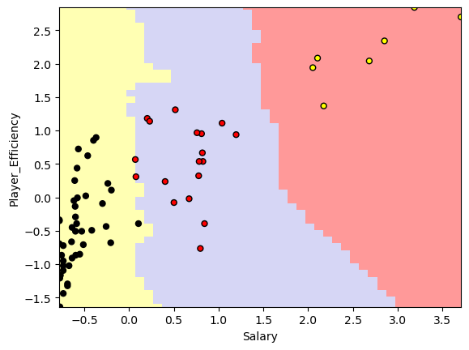

```python
predictKNN(df_1_test, clustered = df_1_clustered, feature_cols=["Salary", "Player_Efficiency"], axis="Player_Efficiency")
```

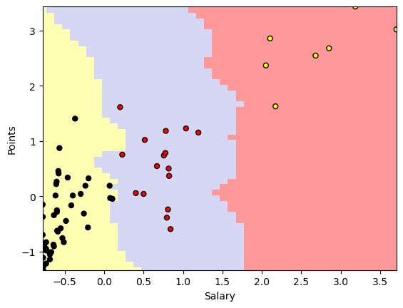

```python
predictKNN(df_2_test, clustered = df_2_clustered, feature_cols=["Salary", "Points"], axis="Points")
```

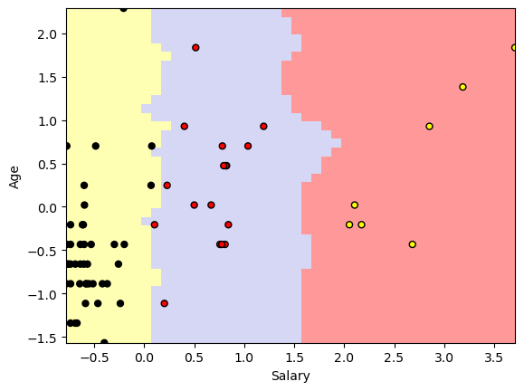

```python
predictKNN(df_3_test, clustered = df_3_clustered, feature_cols=["Salary", "Age"], axis="Age")
```

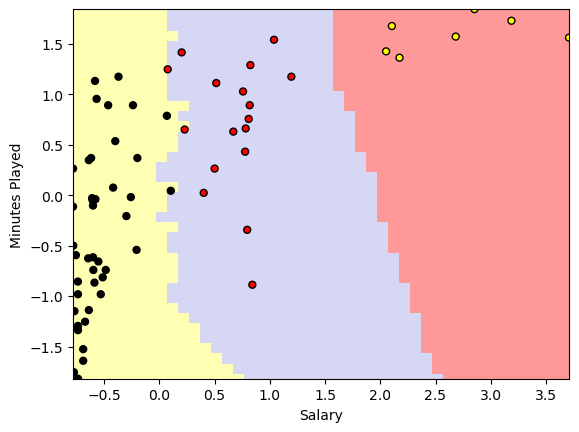

```python
predictKNN(df_4_test, clustered = df_4_clustered, feature_cols=["Salary", "Minutes"], axis="Minutes Played")
```

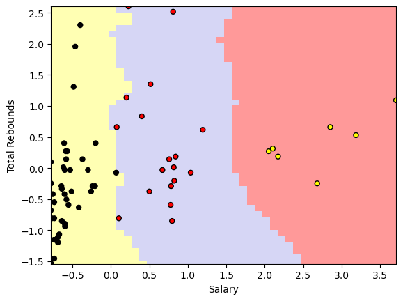

```python
predictKNN(df_5_test, clustered = df_5_clustered, feature_cols=["Salary", "Total_Rebounds"], axis="Total Rebounds")
```